# Quantifying evidence

Ben Whalley, Paul Sharpe, Sonja Heintz

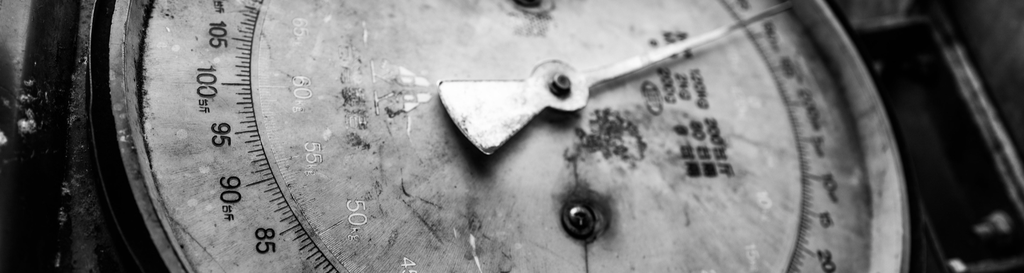

# Overview

In the previous workshop we learned techniques to describe and summarise data. Now we take the next step quantify how *sure* we are that the patterns are real, using the *Bayes Factor*.

The Bayes Factor (BF) is a single number which allows us to choose between different *possible* hypotheses (explanations) of how our data were generated, based on which is most probable.

The important thing to remember about Bayes Factors is that they *compare two possible hypotheses* about how the data came about. The *meaning* of the Bayes Factor completely depends on which hypotheses we compare.

# Is this pattern a fluke?

[video not shown]

**Video summary**

- In all data there is *sampling error* or *‘noise’*
- Patterns caused by noise will not replicate
- Bayes Factors quantify the evidence for patterns
- We *compare the probability* of two scenarios:
  1. the difference we see is ‘real’, and
  2. any difference is a ‘fluke’
- By convention, large Bayes Factor mean the pattern is ‘real’

**Code examples**

**Video Transcript**

Whenever we collect data, there is some element of chance. If the data we have are limited, it’s possible that any patterns have only occurred by chance. We need to be able to quantify how much information our data provide — that is, how much more or less confident about the patterns we are after we make observations.

### Bayes Factors for *differences*

Previously, we emphasised that summaries and descriptions of data are used *to answer research questions*.

For example, we used a boxplot to compare the differences in the amount of weight participants lost when treated with either Functional Imagery Training or Motivational Interviewing (the `funimagery` dataset). This lets us answer the question: *“which intervention was more effective in helping participants lose weight?”*:

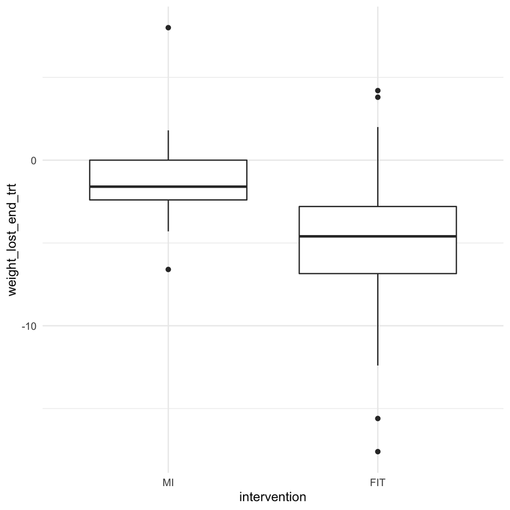

This boxplot shows the *median* and *interquartile range* for each treatment group. It’s immediately obvious that — *in this sample* — there is a difference between the two groups (3.8 kg, in fact), and that — *in this sample* — FIT helped people lose more weight than MI.

For many purposes this plot is enough.

The difference here is quite large and we can interpret this graph at face value. If the costs of these interventions were similar (i.e. if ‘all other things are equal’) it we should choose FIT rather than MI.

However, researchers often want to *quantify the evidence* provided by the sample of data they collect. This is important in psychology, and other sciences, because the size of the effects we see are often quite small or subtle.

It *might* be the case that patterns we see are just a ‘fluke’. That is, they have come about by chance. Perhaps if we took another sample from the same population (treated more people with FIT and MI) then we would see no difference?

The Bayes Factor quantifies how confident we should be about any given pattern in our by comparing two possibilities:

1. There really is a difference in how much weight people lost with FIT and MI (we call this H1)
2. There’s NO difference between FIT and MI; any difference we see is likely to be a fluke (H0)

### Bayes Factors for *correlations*

We have also seen how a scatterplot describes the *relationship* between two columns of data:

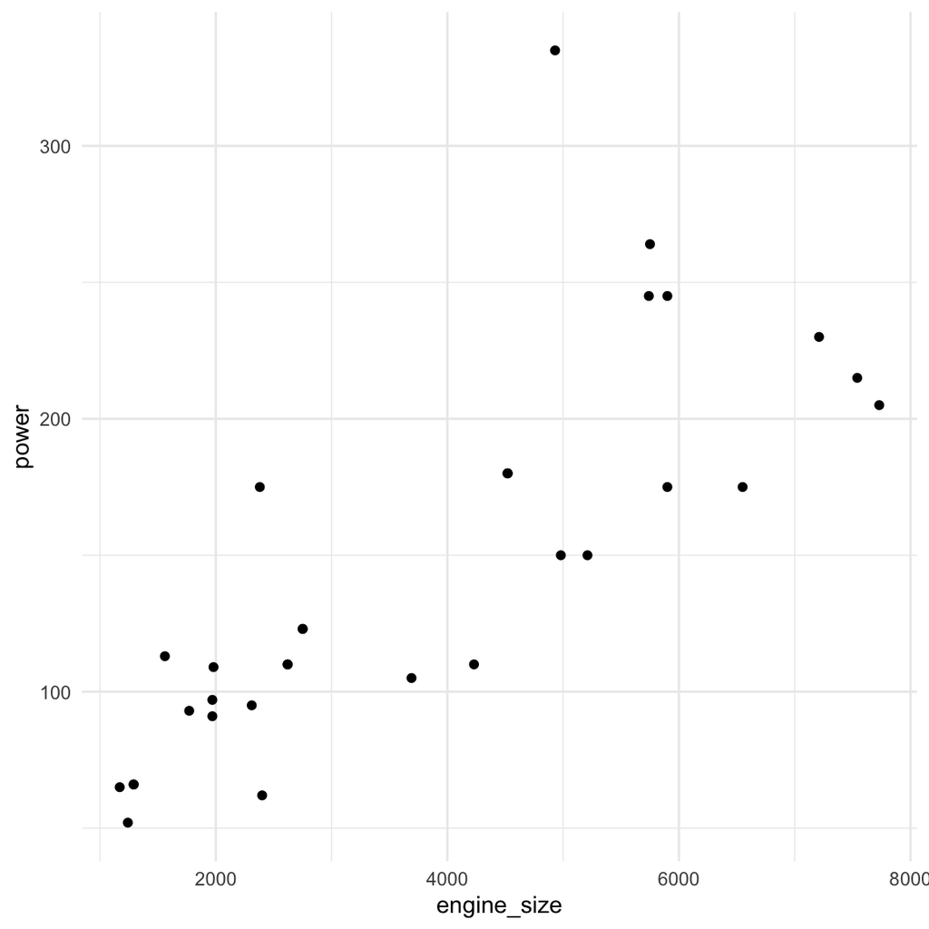

From this plot the relationship seems quite clear, and the correlation between these columns is 0.79

However, we don’t have that many data points, so the pattern *might* have happened by chance.

The Bayes Factor allows us to quantify how much evidence we have for this correlation. As before, we are comparing two different possibilities:

1. There is a correlation between `engine_size` and `power`
2. There is **NO** correlation (the pattern is just a fluke)

# Do it: Bayesian t test

[video not shown]

**Video summary**

- t-tests *compare the average score for two groups*
- A Bayes Factor from a t-test compares two hypotheses:
  - H1: the groups are *different*, vs.
  - H0: the groups are *identical*
- Use the `ttestBF` function in R (load `BayesFactor` first)
- Bayes Factors range from zero to infinity
- Large Bayes Factors are evidence *for some difference*
- Check which *direction* with a boxplot

**Code examples**

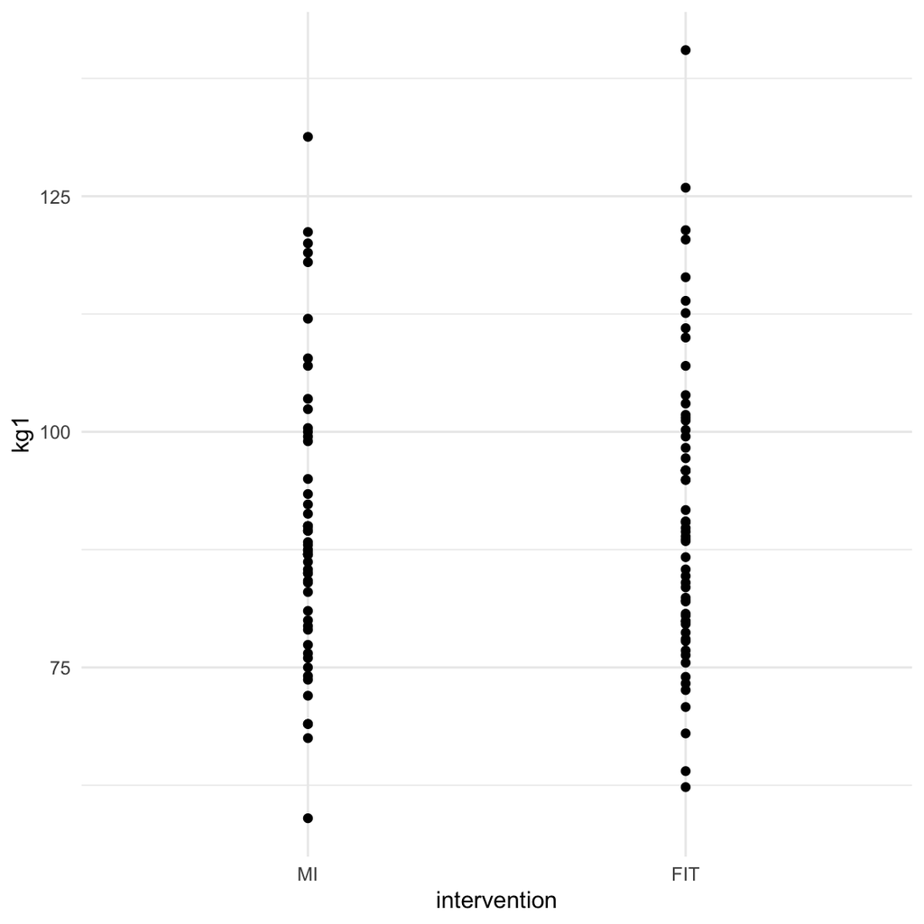

```r
# load packages first
library(psydata)
library(BayesFactor)


funimagery %>% ggplot(aes(intervention, kg1))+ geom_point()
```

```r
# use `formula = ` to tell ttestBF which data to use
# the tilda symbol, ~, means "is predicted by"
ttestBF(formula = weight_lost_end_trt ~ intervention, data=funimagery)
Bayes factor analysis
--------------
[1] Alt., r=0.707 : 515647.5 ±0%

Against denominator:
  Null, mu1-mu2 = 0
---
Bayes factor type: BFindepSample, JZS
```

**Video Transcript**

A ‘Bayesian t-test’ is a procedure which calculates the Bayes Factor for a difference between groups.

That is, we get a Bayes Factor which tells us how likely the difference we see is to be ‘real’, rather than a fluke or due to sampling variation.

Specifically, the Bayes Factor from a Bayesian t-test says how probable it is that two groups have a *different average score* for a *continuous variable*. This probability is *relative* to an alternative hypothesis that the average of each group is actually the same.

Some people call these the *experimental* and *null* hypotheses, or H1 and H0.

As we saw above, we can look at a boxplot and get an intuition for whether we think the difference is real by looking at how much the *distributions* of the two groups overlap (e.g. with the boxplot).

If find a large Bayes Factor, this is evidence *for* the experimental hypothesis, as compared with the null hypothesis.

### Running a t-test

To run a t-test and calculate the Bayes Factor we first need to load the `BayesFactor` package:

```r
library(psydata)
library(BayesFactor)
```

And then use the `ttestBF` function.

```r
ttestBF(formula = weight_lost_end_trt ~ intervention, data=funimagery)
Bayes factor analysis
--------------
[1] Alt., r=0.707 : 515647.5 ±0%

Against denominator:
  Null, mu1-mu2 = 0
---
Bayes factor type: BFindepSample, JZS
```

- Write out the ttestBF code
- explain this is an old function, so looks slightly different
- explain the formula
- outcome variable to the left
- the tilde symbol in the middle, means “is predicted by”
- then the group variable on the right
- we use `data=funimagery` to say which data

The important part of the code here is where we write: `weight_lost_end_trt ~ intervention`. This tells R which column to use as the *outcome* and which to use as the group *predictor*. The tilde symbol, `~`, just means “is predicted by”.

```r
fitbf <- ttestBF(formula = weight_lost_end_trt ~ intervention, data=funimagery) %>%
  as_tibble() %>% pull(bf) %>% .[1]
```

We explain how to interpret Bayes Factors in more detail in the section below, but large numbers are evidence *for* a difference.

- Use the `funimagery` dataset
- Plot participants’ weights at baseline (`kg1`) in each intervention group
- Use `summarise()` to calculate the difference between the groups weight
- Use `with()` and `ttestBF()` to calculate the Bayes Factor for this difference

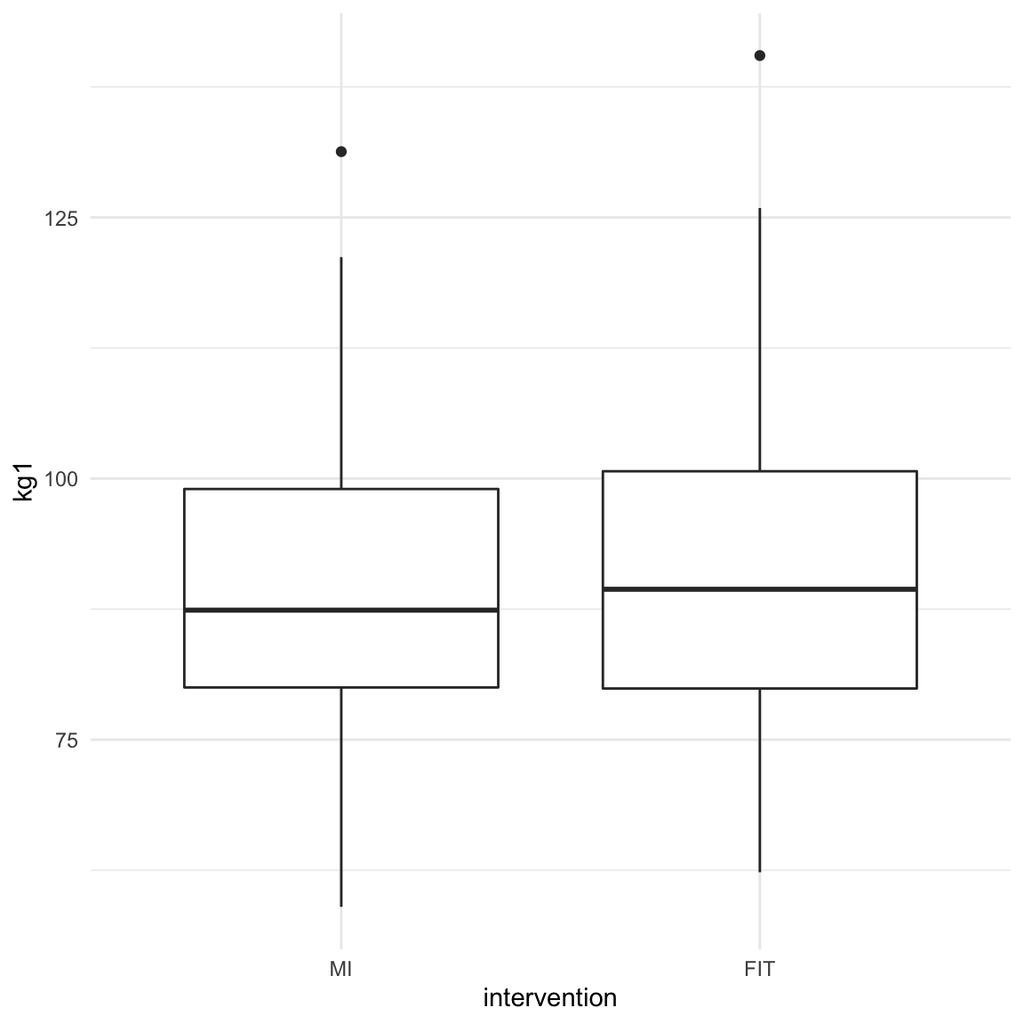

```r
funimagery %>%
  ggplot(aes(intervention, kg1)) + geom_boxplot()
```

```r
aa <- with(funimagery,  ttestBF(intervention, kg1,posterior=T, iterations=1e4))
aa %>% as_data_frame() %>% group_by
# A tibble: 10,000 x 5
      mu `beta (x - y)`  sig2 delta      g
   <dbl>          <dbl> <dbl> <dbl>  <dbl>
 1  44.8          -89.1  122. -8.08   22.3
 2  46.0          -88.1  143. -7.38   77.1
 3  45.8          -91.1  121. -8.27 1646.
 4  45.8          -86.9  105. -8.50 7708.
 5  46.4          -88.9  125. -7.95   71.9
 6  44.1          -88.2  120. -8.05   58.1
 7  45.6          -87.7  115. -8.19   93.7
 8  45.4          -92.6  103. -9.13  173.
 9  45.7          -89.0  108. -8.57   11.1
10  47.3          -87.2  128. -7.70  169.
# … with 9,990 more rows
```

# Do it: Bayes Factor for correlations

[video not shown]

**Video summary**

- `correlationBF` estimates the Bayes Factor for a correlation
- It compares:
  - H1: There *is a relationship* between two columns of data
  - H0: There *is NO relationship*
- Large Bayes Factors are evidence *for* a relationship

**Code examples**

```r
# make a copy of the happy data, including only data from 2019
happy.2019 <- happy %>%
  filter(year == 2019)

# calculate the correlation coefficient first
happy.2019 %>% select(happiness, perceptions_of_corruption) %>% correlate()
# A tibble: 2 x 3
  term                      happiness perceptions_of_corruption
  <chr>                         <dbl>                     <dbl>
1 happiness                    NA                        -0.425
2 perceptions_of_corruption    -0.425                    NA


# use `with()` to tell `correlationBF` which dataset to use
with(happy.2019,  correlationBF(happiness, perceptions_of_corruption))
Bayes factor analysis
--------------
[1] Alt., r=0.333 : 70351.73 ±0%

Against denominator:
  Null, rho = 0
---
Bayes factor type: BFcorrelation, Jeffreys-beta*
```

**Video Transcript**

A Bayes Factor for a correlation compares the two hypotheses that either:

- H1: There is a relationship between the two columns of data
- H0: There is NO relationship (any pattern is just due to chance)

Another way to think about it is to imagine we have a set of data points like this:

```
# A tibble: 2 x 3
  term       y      x
  <chr>  <dbl>  <dbl>
1 y     NA      0.693
2 x      0.693 NA
```

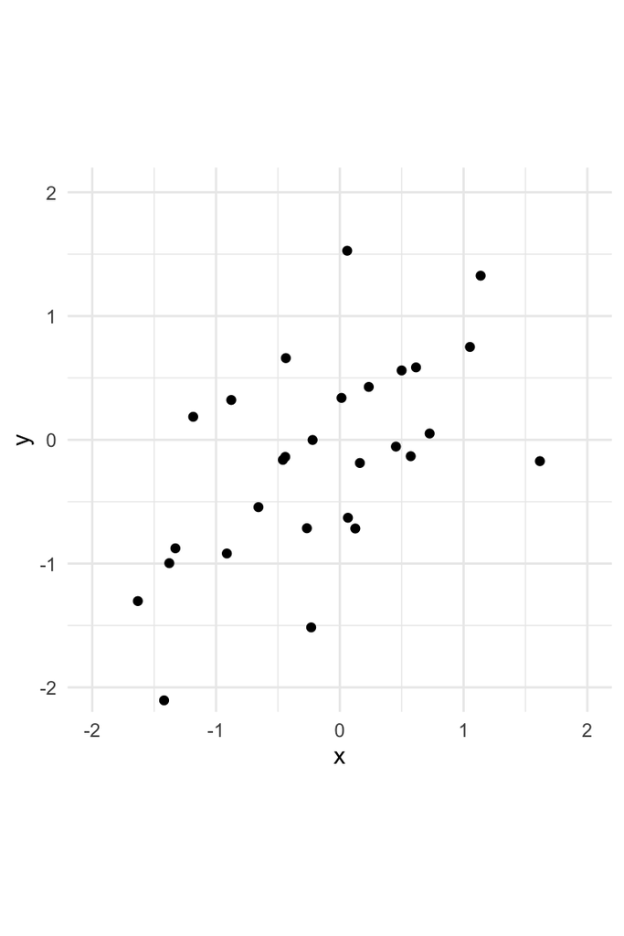

We ask: *if we wanted to draw a straight line through all the data points, which would be the best fit?* Which line would fall the closest to all the data points?

The plot below shows some examples of lines we could draw.

Zero correlation is drawn in blue.

Examples of other *possible* coefficients are shown in red (but remember, it could be anything from -1 to 1).

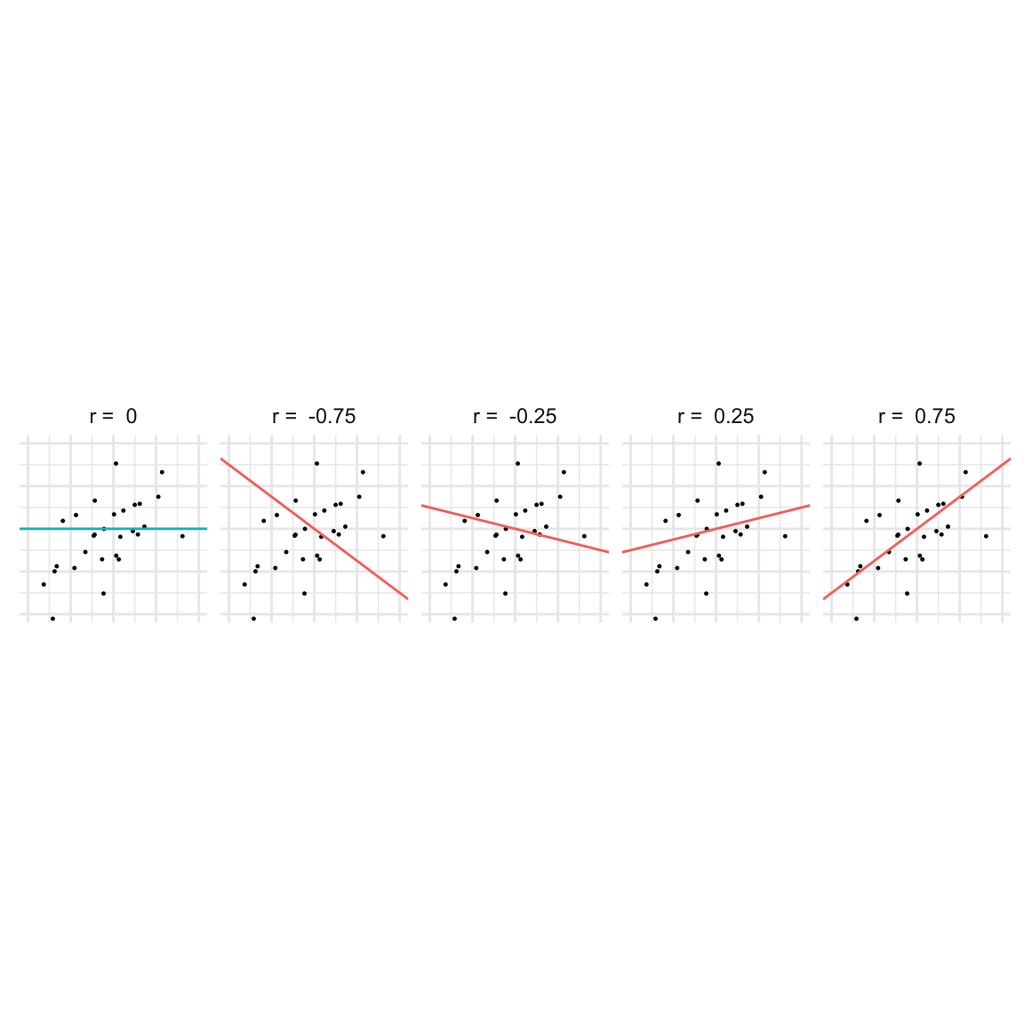

The Bayes Factor tells us: *“Are ANY of the red lines a better fit than the blue line?”*

The Bayes Factor is comparing the change that ANY of the red lines (where $r > 0$ or $r < 0$) are a better fit than the blue line, where $r = 0$.

Another way to say it is, *“given the data we have collected, how much more likely is it that the correlation is non-zero, than actually being zero?”*

### A worked example

We want to check the relationship of two variables in the `happy` dataset, which is based on the [Gallup World Happiness Report 2021](https://worldhappiness.report/ed/2021/):

The first thing to do is to plot the data, to check that the relationship between these variables is approximately linear (a straight line). Here I have used `filter` to select only the data from 2019.

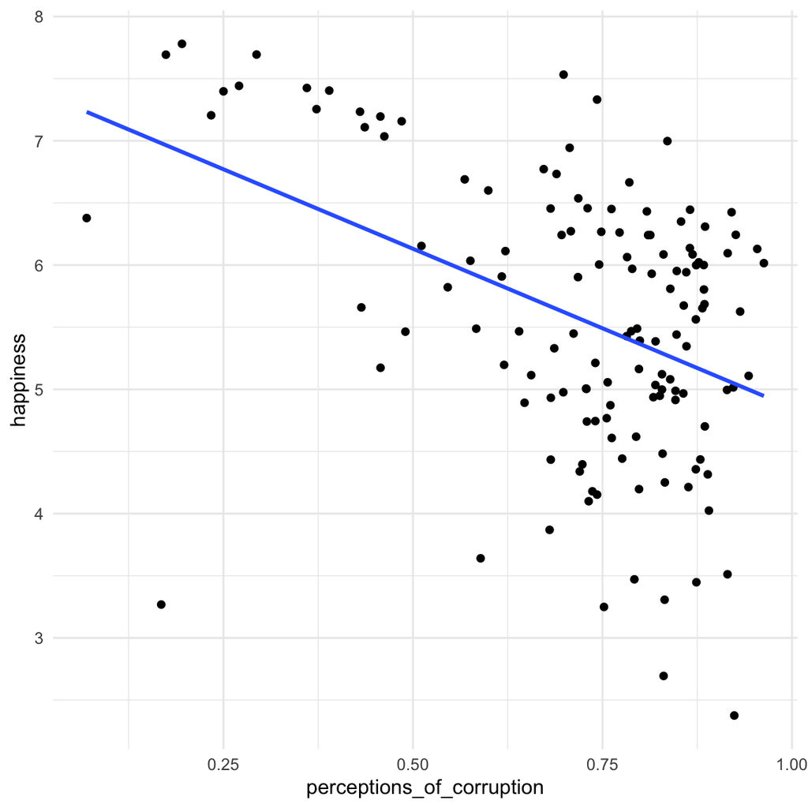

```r
happy %>%
  filter(year==2019) %>%
  ggplot(aes(perceptions_of_corruption, happiness)) +
  geom_point() +
  geom_smooth(method=lm, se=F)
Warning: Removed 8 rows containing non-finite values (stat_smooth).
Warning: Removed 8 rows containing missing values (geom_point).
```

We can check the correlation using `select` and `correlate()`:

```r
happy  %>%
  filter(year == 2019) %>%
  select(happiness, perceptions_of_corruption) %>%
  correlate()
# A tibble: 2 x 3
  term                      happiness perceptions_of_corruption
  <chr>                         <dbl>                     <dbl>
1 happiness                    NA                        -0.425
2 perceptions_of_corruption    -0.425                    NA
```

So - the question now is, how much evidence do we have that the correlation is ‘real’, and that this pattern isn’t just a fluke.

```r
# first, make a copy of the happy data, including only data from 2019
happy.2019 <- happy %>% filter(year == 2019)
```

```r
with(happy.2019,  correlationBF(happiness, perceptions_of_corruption))
Bayes factor analysis
--------------
[1] Alt., r=0.333 : 70351.73 ±0%

Against denominator:
  Null, rho = 0
---
Bayes factor type: BFcorrelation, Jeffreys-beta*
```

Now, the Bayes Factor is 70352.

That means we can be *very* confident that the pattern we see is not simply due to chance.

# Interpreting Bayes Factors

The size of a Bayes Factor is mostly dependent on three things:

- *How large* the effect is (how big is the group difference or how steep is the slope)
- *How clear* the difference is (e.g., how much do the scores from each group overlap)
- *How much data* we collect (more data lets us be more confident; data quality also matters)

We return to this topic later but for now just remember that:

- A Bayes Factor or 1 means each hypothesis is equally likely
- A Bayes factor > 3 is a common threshold for thinking an effect is ‘real’ (although this threshold is arbitrary)
- A Bayes Factor $< \frac{1}{3}$ is evidence *against* the effect being real
- If the Bayes Factor is $> \frac{1}{3}$ and $<3$ then we say the result is *inconclusive*.

# Test your knowledge

- What hypotheses are being compared when we calculate a Bayes Factor for a correlation?
- Which function do we recommend to calculate correlation coefficients?
- Which function calculates the Bayes Factor for a correlation?
- Which function calculates the Bayes Factor for a difference in the average of two groups?
- What direction slope does a correlation of -0.5 imply? What would the scatterplot look like?
- What conclusion should we draw if the Bayes Factor for a correlation is 2.1? How about if it was 0.21, or 210?
- What conclusion should we draw if the Bayes Factor for a t test is 0.8? How about if it were > 10?